# SAPFLUXNET: Una base de datos global de medidas de flujo de savia

26 de abril de 2018

## La transpiración como principal flujo evaporativo global

- La transpiración representa globalmente un ~60% de la ET terrestre y los bosques transpiran un ~60% de esta ET.

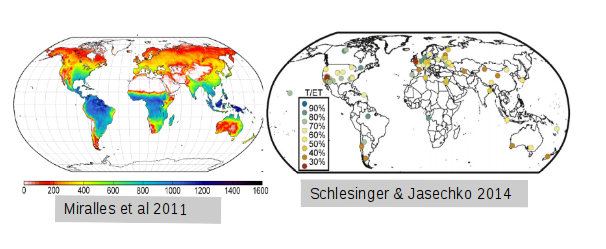

## Regulación de la transpiración y resistencia a la sequía

- La regulación de la transpiración se refleja en la magnitud y los patrones temporales del flujo de savia.

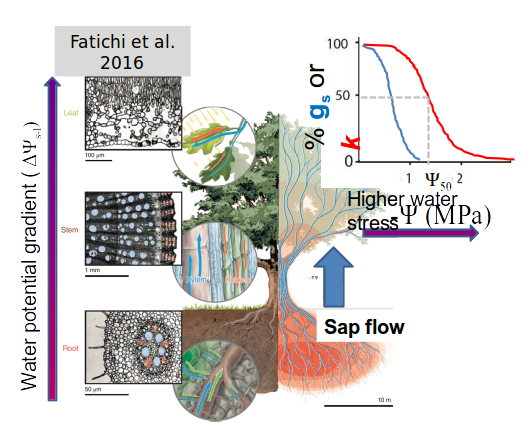

## Medida de flujo de savia con métodos térmicos

- El flujo de savia es la medida de los patrones temporales del uso de agua, con una mayor representatividad ecológica (especies, poblaciones, tamaños de planta)

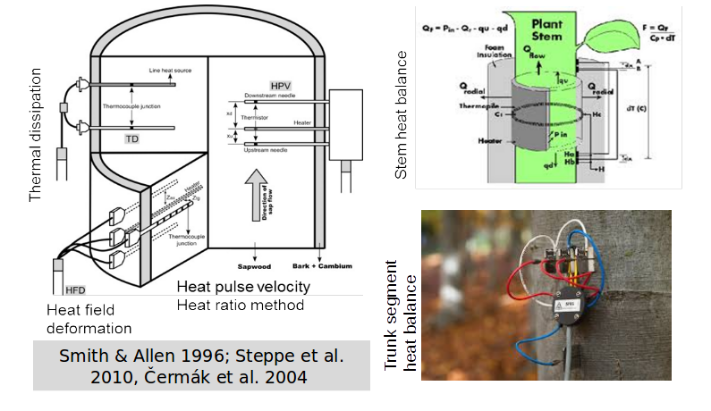

## Datos globales de flujo de savia, por qué no?

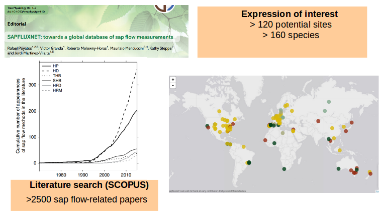

## Progreso actual

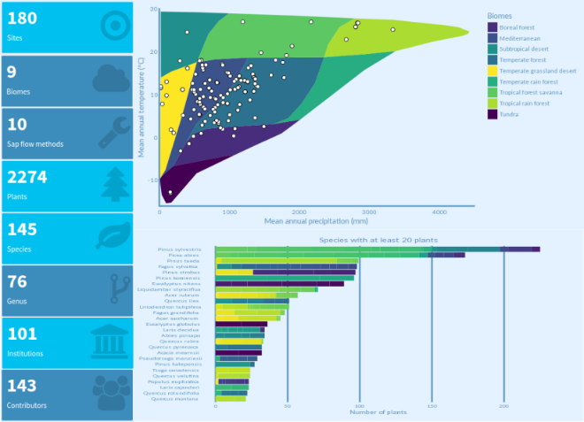

## Descripción técnica

> Para poder asegurar la calidad de los datos recibidos necesitamos un control de calidad **semi-automático**, **reproducible** y **robusto**. También necesitamos, por otro lado, almacenar los datos de tal manera que permita el acceso a toda la información (datos y metadatos) para simplificar el proceso.

## Control de calidad

[figure not shown]

## Almacenamiento de los datos

Toda la información de un sitio (datos de flujo, datos ambientales, metadatos de sitio, stand, especies, plantas y ambientales) se combinan en un solo objeto, gracias a la clase S4 `sfn_data`:

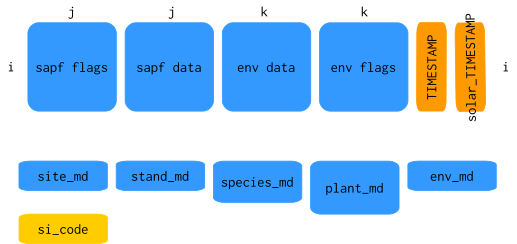

## Almacenamiento de los datos

Así, es sencillo acceder a los datos de flujo, por ejemplo:

```r
read_sfn_data('ARG_MAZ') %>% get_sapf_data()
```

```
## # A time tibble: 288 x 6
## # Index: TIMESTAMP
##    TIMESTAMP           ARG_MAZ_Npu_Jt_1 ARG_MAZ_Npu_Jt_2 ARG_MAZ_Npu_Jt_3
##    <dttm>                         <dbl>            <dbl>            <dbl>
##  1 2009-11-19 00:00:00            1955.             754.             742.
##  2 2009-11-19 01:00:00            1833.             752.             631.
##  3 2009-11-19 02:00:00            1817.             795.             597.
##  4 2009-11-19 03:00:00            1598.             788.             579.
##  5 2009-11-19 04:00:00            1419.             780.             518.
##  6 2009-11-19 05:00:00            1506.             735.             430.
##  7 2009-11-19 06:00:00            1649.             720.             539.
##  8 2009-11-19 07:00:00            1630.             882.             542.
##  9 2009-11-19 08:00:00            1909.            1015.             655.
## 10 2009-11-19 09:00:00            2849.            1459.             930.
## # ... with 278 more rows, and 2 more variables: ARG_MAZ_Npu_Jt_4 <dbl>,
## #   ARG_MAZ_Npu_Jt_5 <dbl>
```

## Herramientas desarrolladas en el proyecto

Monitorización del Control de Calidad y del progreso del proyecto, gracias a aplicaciones `shiny`:

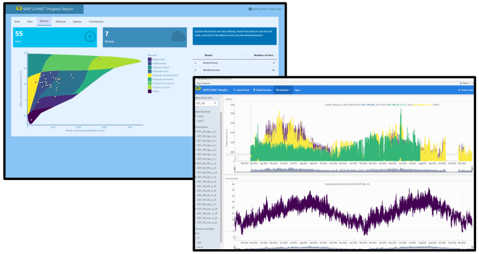

## Herramientas desarrolladas en el proyecto

Paquetes de R para trabajar con los datos

- `sapfluxnetQC1`:  
  Encargado de toda la parte semi-automática de control de calidad. Destinado a uso interno del proyecto, pero auditable por cualquier interesado (Data contributors, Journal reviewers…):  
  https://github.com/sapfluxnet/sapfluxnetQC1
- `sapfluxnetr`:  
  Herramientas y utilidades para el análisis de los datos recopilados en SAPFLUXNET. Destinado al público interesado (Data contributors, Investigadores…) y completamente disponible:  
  https://github.com/sapfluxnet/sapfluxnetr

## Escalado del uso del agua

SAPFLUXNET permitirá analizar la variación de la transpiración en función de atributos de la planta (diámetro, área de albura, área foliar).

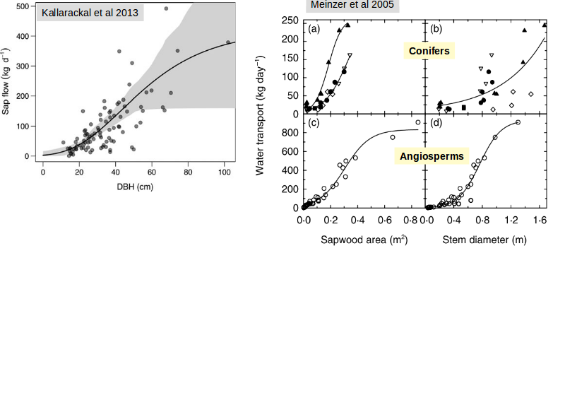

## Escalado del uso de agua

Con datos de SAPFLUXNET

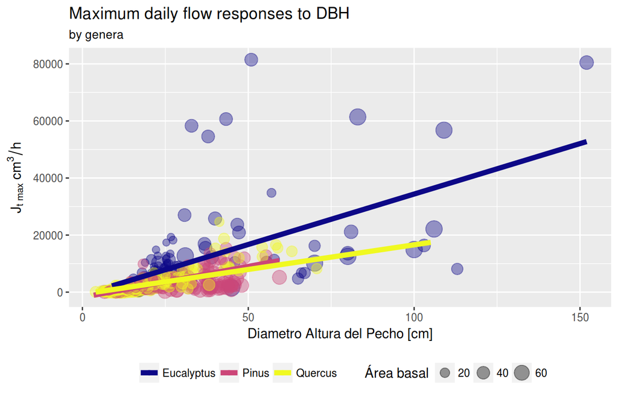

## Respuestas a la demanda evaporativa

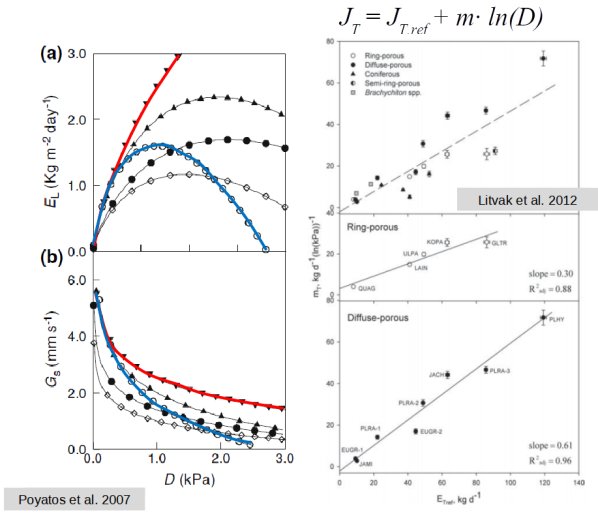

## Respuestas a la demanda evaporativa

Con datos de SAPFLUXNET

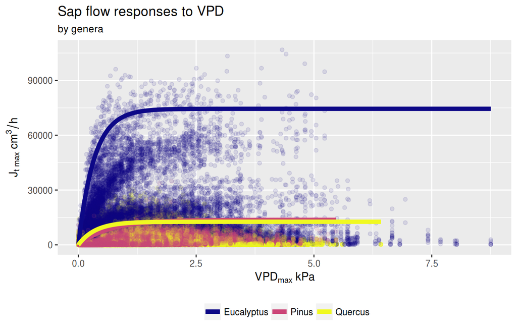

## Respuestas a la humedad del suelo

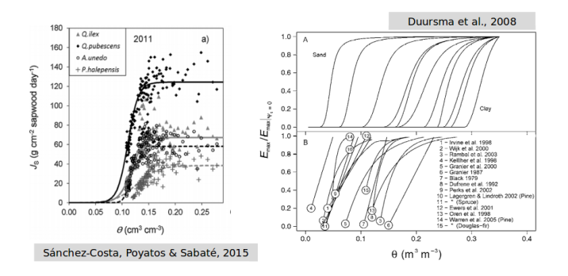

## Respuestas temporales

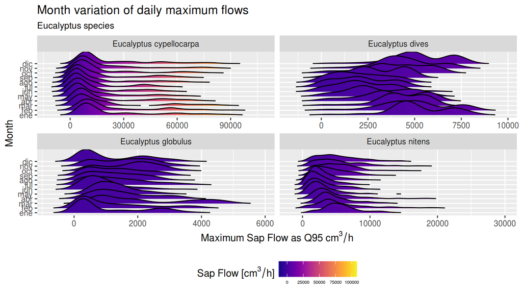

## Respuestas temporales

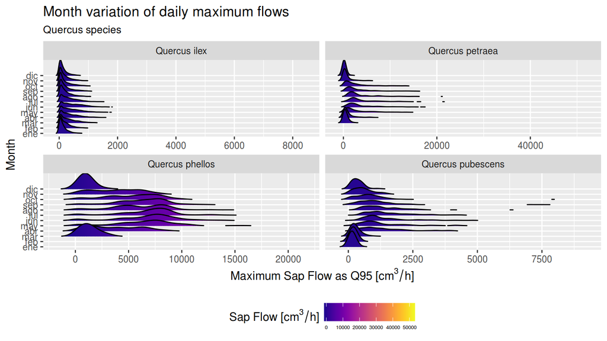

## Agradecimientos

**Gracias por la atención!!**

Este proyecto está financiado por el Ministerio de Economía y Competitividad

y no hubiese sido posible sin la amable colaboración de todos los *“data contributors”*.

[figure not shown]